# A4 - Anàlisi estadística avançada

Xavier Maltas Tarridas

January 2023

# 1 Preprocessament

En primer lloc, realitzem la càrrega del fitxer de dades. Seguidament, elaborem una breu anàlisi de la mostra de dades, així com una cerca i correcció de les possibles inconsistències en les dades.

```r
#Load file
df <- read.csv("Fumadores.csv", sep=";")

###DF descriptive analysis
#Dimensions
dim(df)
```

```
## [1] 253   4
```

```r
#df structure
str(df)
```

```
## 'data.frame':    253 obs. of  4 variables:
##  $ AE    : chr  "1.871878" "1.91312" "2.58114" "2.17827" ...
##  $ Tipo  : chr  "NF" "NF" "NF" "NF" ...
##  $ genero: chr  "M" "F" "M" "F" ...
##  $ edad  : int  54 60 40 55 59 63 62 62 26 48 ...
```

```r
#Head data sample
head(df)
```

```
##         AE Tipo genero edad
## 1 1.871878   NF      M   54
## 2  1.91312   NF      F   60
## 3  2.58114   NF      M   40
## 4  2.17827   NF      F   55
## 5 1.707732   NF      F   59
## 6 1.561215   NF      F   63
```

```r
#Summary
summary(df)
```

```
##       AE                Tipo              genero               edad
##  Length:253         Length:253         Length:253         Min.   :17.00
##  Class :character   Class :character   Class :character   1st Qu.:43.00
##  Mode  :character   Mode  :character   Mode  :character   Median :50.00
##                                                           Mean   :49.76
##                                                           3rd Qu.:57.00
##                                                           Max.   :78.00
```

```r
#Class per each var
sapply(df,class)
```

```
##          AE        Tipo      genero        edad
## "character" "character" "character"   "integer"
```

```r
## NA values
colSums(is.na(df))
```

```
##     AE   Tipo genero   edad
##      0      0      0      0
```

```r
#Transform without units, comma -> dot and numeric datatype
cleanAndExtractNum <- function(row){
  num <- gsub("[a-zA-Z ]", "", row) #Elimiem caracters
  num <- as.numeric(gsub(",", ".",num)) #Comma to dot, to numeric
}

#AE cleaning
df$AE <- cleanAndExtractNum(df$AE)

#Tipo unique values and standarization
unique(df$Tipo)
```

```
##  [1] "NF"     "FP"     "NI"     "FL"     "FM  "   "  FM  " "FM"     "fm"
##  [9] "FI"     "fi"
```

```r
df$Tipo[df$Tipo == "  FM  " ] <- "FM"
df$Tipo[df$Tipo == "FM  "] <- "FM"
df$Tipo[df$Tipo == "fm" ] <- "FM"
df$Tipo[df$Tipo == "fi" ] <- "FI"

#Numeric Tipo value
smokerTypeToInteger <- function(input) {
  input [input == "NF"] <- 0
  input [input == "FP"] <- 1
  input [input == "NI"] <- 2
  input [input == "FL"] <- 3
  input [input == "FM"] <- 4
  input [input == "FI"] <- 5
  input <- as.integer(input)
}
df$TipoNumeric <- smokerTypeToInteger(df$Tipo)

#Gender numeric value
unique(df$genero)
```

```
## [1] "M" "F"
```

```r
genderTointeger <- function(input) {
  input [input == "M"] <- 0
  input [input == "F"] <- 1
  input <- as.integer(input)
}
df$generoNumeric <- genderTointeger(df$genero)

#NA check
colSums(is.na(df))
```

```
##            AE          Tipo        genero          edad   TipoNumeric
##             0             0             0             0             0
## generoNumeric
##             0
```

```r
head(df)
```

```
##         AE Tipo genero edad TipoNumeric generoNumeric
## 1 1.871878   NF      M   54           0             0
## 2 1.913120   NF      F   60           0             1
## 3 2.581140   NF      M   40           0             0
## 4 2.178270   NF      F   55           0             1
## 5 1.707732   NF      F   59           0             1
## 6 1.561215   NF      F   63           0             1
```

# 2 Anàlisi descriptiva de la mostra

## 2.1 Capacitat pulmonar i gènere

Realitzem un diagrama de caixes i un de densitat per a mostrar la relació entre la capacitat pulmonar en funció al gènere.

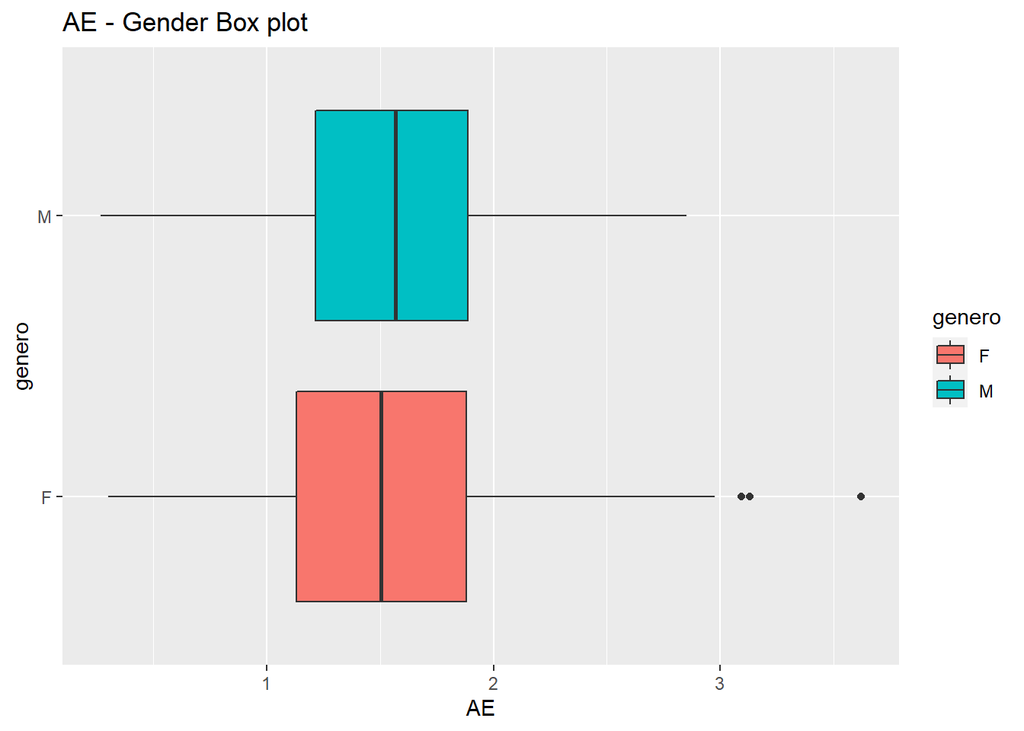

```r
#Box plot
ggplot(df, aes(x=AE, y=genero, fill=genero)) + geom_boxplot() + guides() + ggtitle("AE - Gender Box plot")
```

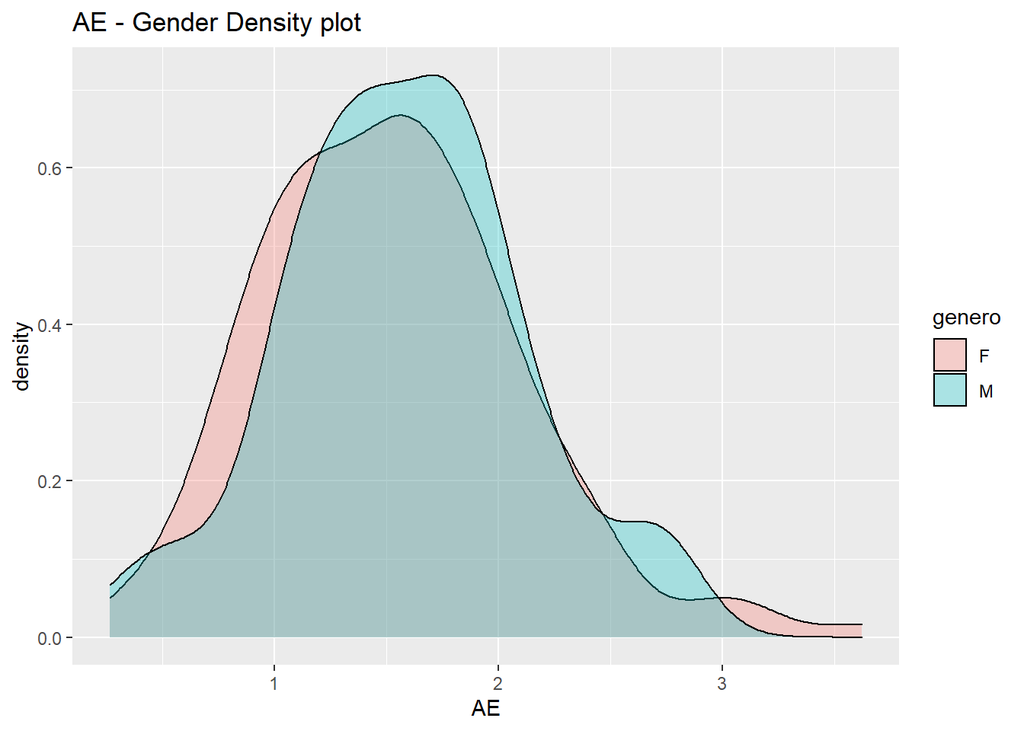

```r
# Density plots
ggplot(df, aes(x=AE, fill=genero)) + geom_density(alpha=.3) + ggtitle("AE - Gender Density plot ")
```

## 2.2 Capacitat pulmonar i edat

Realitzem un gràfic de dispersió per a mostrar la relació entre la capacitat pulmonar i l’edat.

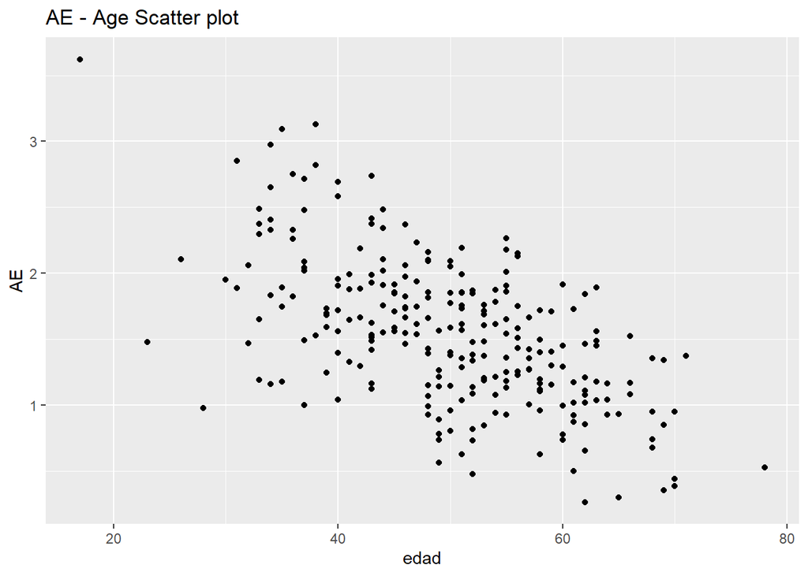

```r
#Scatterplot AE-Age
ggplot(df, aes(edad, AE)) + geom_point() + ggtitle("AE - Age Scatter plot ")
```

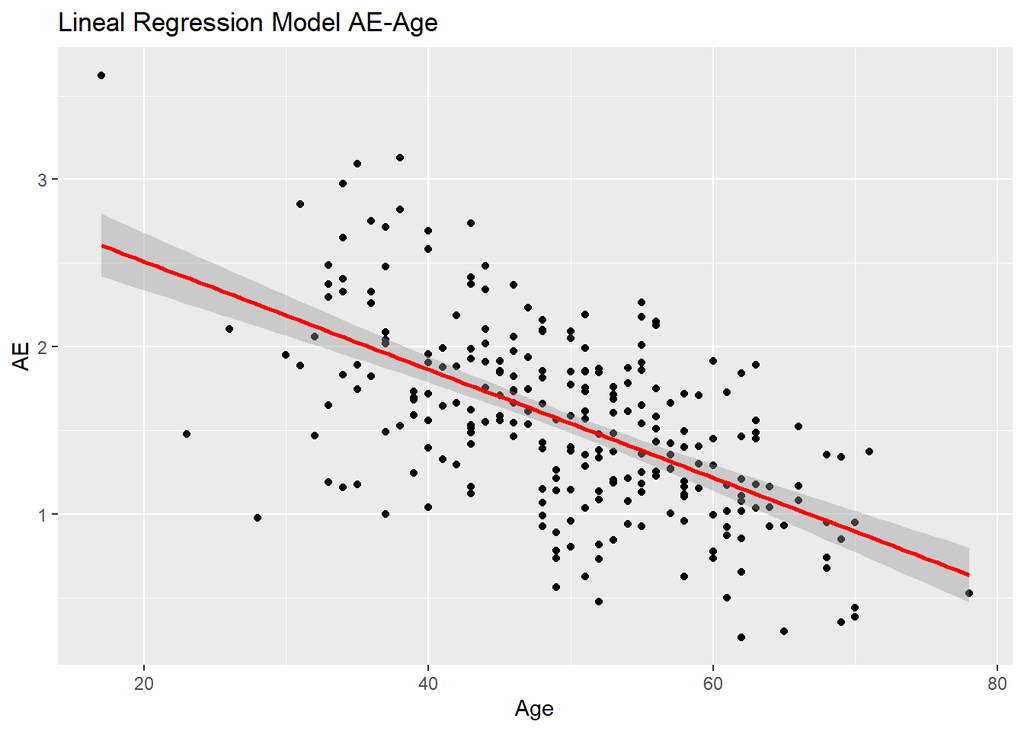

```r
#Linear Regression model plot over scatter plot AE-Age
ggplot(df, aes(edad, AE))+ geom_point() + ggtitle("Lineal Regression Model AE-Age") + xlab("Age") + ylab("AE") +  stat_smooth(method = "lm", col = "red")
```

Observant el gràfic de dispersió realitzat, podem veure que hi ha una relació entre la capacitat pulmonar i l’edat de la persona. Els valors corresponents a la capacitat pulmonar segueixen una tendència a la baixa a mesura que el valor de l’edat incrementa. Per a veure de forma més clara, hem aplicat al gràfic de dispersió una regressió lineal, que ens mostra de forma clara la tendència esmentada. Finalment, també hem volgut mostrar els mateixos gràfics anteriors, però afegint el factor del gènere.

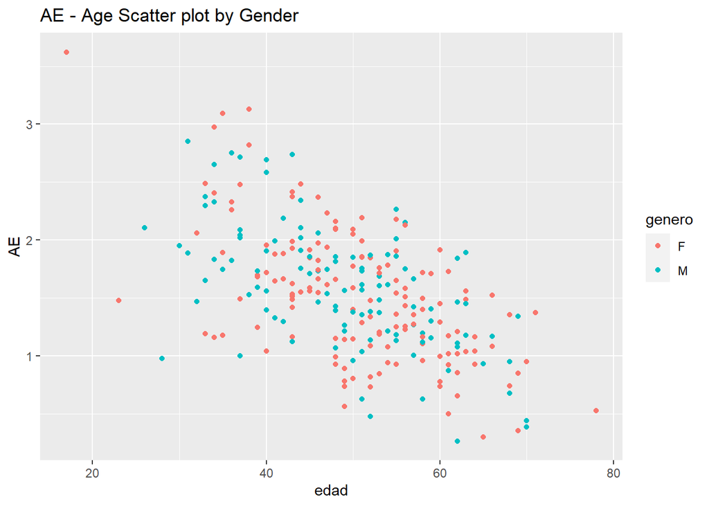

```r
#Scatterplot AE-Age color by gender
ggplot(df, aes(edad, AE)) + geom_point(aes(color=genero)) + ggtitle("AE - Age Scatter plot by Gender")
```

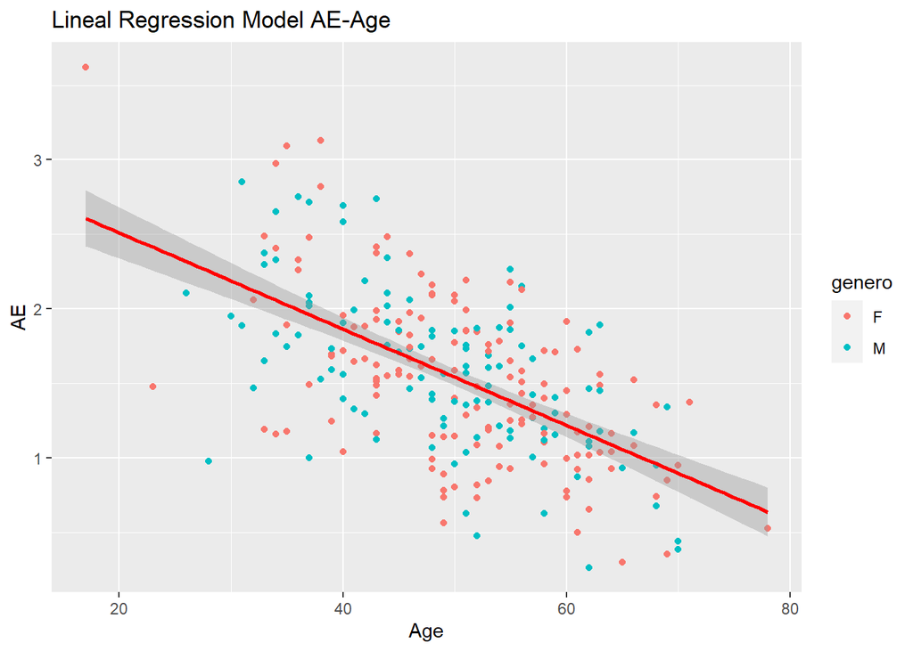

```r
#Linear Regression model plot over scatter plot AE-Age color by gender
ggplot(df, aes(edad, AE))+ geom_point(aes(color=genero)) + ggtitle("Lineal Regression Model AE-Age") + xlab("Age") + ylab("AE") +  stat_smooth(method = "lm", col = "red")
```

## 2.3 Tipus de fumadors i capacitat pulmonar

Realitzem un data frame amb el nombre de persones en cada tipus de fumador i la mitjana de AE de cada tipus de fumador. A continuació, realitzem un gràfic de barres on mostrem de forma decreixen el valor mitja AE de cada tipus de fumador.

```r
library(dplyr)
#DF smoker type, n elements and AE mean
df.byTipoMeanAE <- df %>% group_by(Tipo) %>% summarise(total_count=n(), mean_AE=mean(AE), .groups = 'drop') %>% arrange(desc(mean_AE)) %>% as.data.frame()
df.byTipoMeanAE
```

```
##   Tipo total_count  mean_AE
## 1   NF          50 1.992625
## 2   NI          42 1.634737
## 3   FP          40 1.620952
## 4   FL          41 1.556476
## 5   FI          41 1.217035
## 6   FM          39 1.157442
```

```r
#Barplot decreasing meanAE value
df.byTipoMeanAE[order(df.byTipoMeanAE$mean_AE,decreasing = TRUE),]
```

```
##   Tipo total_count  mean_AE
## 1   NF          50 1.992625
## 2   NI          42 1.634737
## 3   FP          40 1.620952
## 4   FL          41 1.556476
## 5   FI          41 1.217035
## 6   FM          39 1.157442
```

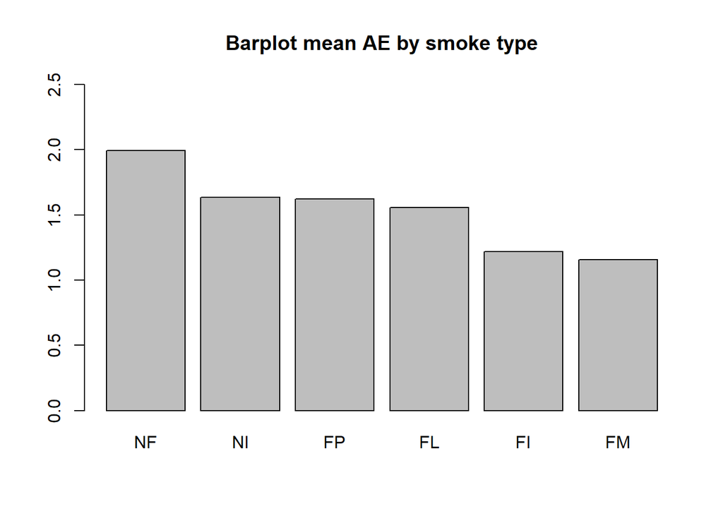

```r
barplot(df.byTipoMeanAE$mean_AE,names.arg = df.byTipoMeanAE$Tipo, main="Barplot mean AE by smoke type",ylim = c(0, 2.5))#, horiz=T , las=1)
```

Finalment, realitzem un diagrama de caixes on es mostri la distribució del paràmetre AE per a cada tipus de fumador. Mitjançant aquest gràfic podem observar clarament que els no fumadors *(NF)* tenen una major capacitat pulmonar en valor mitjà així com en el rang de les mostres. A continuació, podem trobar els fumadors passius *(FP)* i fumadors que no inhalen fum *(NI)* disposen d’un valor mitjà d’AE similar. Pel que fa al rang de mostres, veiem que el que pertany als fumadors passius *(FP)*, en els valors alts, és similar al dels no fumadors *(NF)*. Per altra banda, els valors baixos són inferiors als dels fumadors que no inhalen fum *(NI)*, que es troben agrupats en un bloc molt compacte. Pel que fa a la capacitat pulmonar dels tres tipus de fumadors restants, veiem que els fumadors lleugers *(FL)* disposen d’una capacitat pulmonar mitjana similar a la dels fumadors passius (FP). En termes de rang de les mostres, la major part d’aquestes es troba al voltant dels valors baixos del rang, tot i això, aquests valors són similars als dels no fumadors. Per acabar, veiem que la capacitat pulmonar mitjana dels fumadors moderats *(FM)* i els fumadors intensius *(FI)* és pràcticament igual. En qüestions de rang de les mostres, per sorpresa, tenim als fumadors moderats *(FM)* amb els pitjors registres de tots els tipus de fumadors, fins i tot per sota dels fumadors intensius *(FI)*.

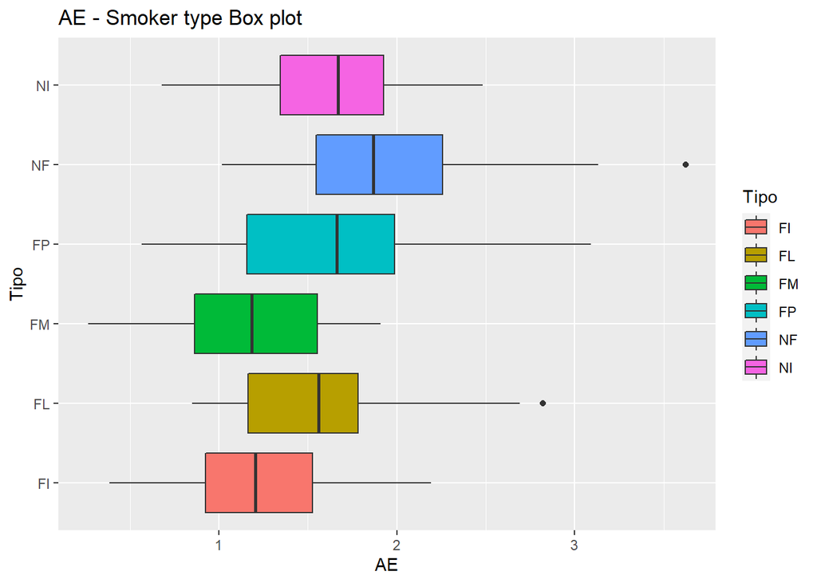

```r
#Box plot AE by Tipo
ggplot(df, aes(x=AE, y=Tipo, fill=Tipo)) + geom_boxplot() + guides() + ggtitle("AE - Smoker type Box plot")
```

# 3 Interval de confiança de la capacitat pulmonar

L’interval de confiança ens permet estimar entre quin rang es trobarà un valor desconegut respecte a un paràmetre poblacional amb un determinat nivell de confiança. En el cas que ens ocupa, volem estimar el rang que es trobarà la capacitat pulmonar de les dones i els homes per separat amb una confiança del 95%.

```r
# Men and female new data frames
df.men <- df %>% filter(genero == "M")
df.female <- df %>% filter(genero == "F")
summary(df.men)
```

```
##        AE             Tipo              genero               edad
##  Min.   :0.2649   Length:109         Length:109         Min.   :26.00
##  1st Qu.:1.2129   Class :character   Class :character   1st Qu.:40.00
##  Median :1.5677   Mode  :character   Mode  :character   Median :49.00
##  Mean   :1.5838                                         Mean   :48.69
##  3rd Qu.:1.8853                                         3rd Qu.:56.00
##  Max.   :2.8499                                         Max.   :70.00
##   TipoNumeric    generoNumeric
##  Min.   :0.000   Min.   :0
##  1st Qu.:1.000   1st Qu.:0
##  Median :2.000   Median :0
##  Mean   :2.312   Mean   :0
##  3rd Qu.:4.000   3rd Qu.:0
##  Max.   :5.000   Max.   :0
```

```r
summary(df.female)
```

```
##        AE             Tipo              genero               edad
##  Min.   :0.3008   Length:144         Length:144         Min.   :17.00
##  1st Qu.:1.1312   Class :character   Class :character   1st Qu.:43.00
##  Median :1.5026   Mode  :character   Mode  :character   Median :50.50
##  Mean   :1.5233                                         Mean   :50.58
##  3rd Qu.:1.8792                                         3rd Qu.:58.00
##  Max.   :3.6226                                         Max.   :78.00
##   TipoNumeric    generoNumeric
##  Min.   :0.000   Min.   :1
##  1st Qu.:1.000   1st Qu.:1
##  Median :3.000   Median :1
##  Mean   :2.472   Mean   :1
##  3rd Qu.:4.000   3rd Qu.:1
##  Max.   :5.000   Max.   :1
```

A continuació realitzem una funció anomenada IC que donat un vector de dades (x) i un nivell de confiança (NC), retorni els intervals de confiança de la mostra.

```r
#IC function
IC <- function(x, NC) {
  n <- length(x)
  mean <- mean(x)
  sd <- sd(x)
  z <- abs(qnorm(((1-NC)/2)))
  errorst <- sd/sqrt(n)
  lim_inf <- mean - (z*errorst)
  lim_sup <- mean + (z*errorst)
  output <- data.frame(NC, n, mean, sd, z, errorst, lim_inf, lim_sup)
  return(output)
}

#Intervals de confinaça
ic95.AE.men <- IC(df.men$AE, 0.95)
ic95.AE.men
```

```
##     NC   n     mean        sd        z    errorst  lim_inf  lim_sup
## 1 0.95 109 1.583762 0.5344087 1.959964 0.05118707 1.483438 1.684087
```

```r
ic95.AE.female <- IC(df.female$AE, 0.95)
ic95.AE.female
```

```
##     NC   n    mean        sd        z    errorst  lim_inf lim_sup
## 1 0.95 144 1.52328 0.5758239 1.959964 0.04798533 1.429231 1.61733
```

L’interval de confiança de la capacitat pulmonar en el cas dels homes és de [1.483438, 1.684087], amb un valor mitjà mostral de 1.583762. Pel que fa al cas de les dones, l’interval de confiança de la capacitat pulmonar és de [1.429231, 1.61733], amb un valor mitjà mostral de 1.52328. La interpretació que podem extreure dels intervals de confiança calculats, és que si repetíssim el mateix procediment amb un nombre elevat de mostres, el 95% dels valors aconseguits de la mostra, es trobaran continguts dins dels intervals de confiança indicats anteriorment. Mitjançant el teorema del límit central, podem assumir que la mitjana mostral segueix una distribució normal, ja que tenim una mostra gran en els dos casos (superior a 30 registres), i podem fer servir la distribució normal per calcular l’interval de confiança. Observant els intervals de confiança obtinguts i els valors mitjans mostrals, podem concloure que la diferència en la capacitat pulmonar entre homes i dones és mínima.

# 4 Diferències en capacitat pulmonar entre dones i homes

En aquest apartat realitzarem un contrast d’hipòtesi per tal d’avaluar si existeixen diferències significatives entre la capacitat pulmonar entre dones i homes.

## 4.1 Hipòtesi

En primer lloc, determinem la hipòtesi nul·la i la hipòtesi alternativa.

$$H_0: AE_{Men} = AE_{Female}$$
$$H_1: AE_{Men} > AE_{Female}$$

## 4.2 Contrast

En aquest apartat justificarem quin és el tipus de test farem servir.

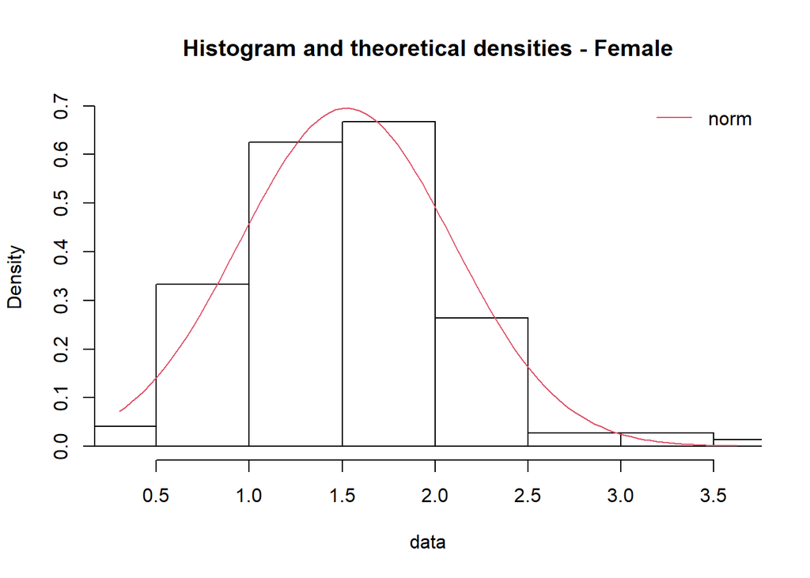

```r
#Female
fit.norm.female.AE <- fitdist(df.female$AE, "norm")
denscomp(fit.norm.female.AE, main= "Histogram and theoretical densities - Female")
```

[figure not shown]

```r
#Male
fit.norm.male.AE <- fitdist(df.female$AE, "norm")
denscomp(fit.norm.male.AE, main= "Histogram and theoretical densities - Male")
```

```r
#FTest
var.test(df.men$AE, df.female$AE)
```

```
##
##  F test to compare two variances
##
## data:  df.men$AE and df.female$AE
## F = 0.86133, num df = 108, denom df = 143, p-value = 0.4152
## alternative hypothesis: true ratio of variances is not equal to 1
## 95 percent confidence interval:
##  0.6066144 1.2339167
## sample estimates:
## ratio of variances
##           0.861326
```

Estem realitzant un test de dues mostres sobre la mitjana de variàncies desconegudes, és per aquest motiu que aplicant el teorema del límit central (TLC) podem assumir normalitat, ja que tal com ens indica el TLC, la mitjana d’una mostra de mida gran (mostra superior a 30 registres) es comporta com una distribució normal. Desconeixem la variància de la població i, per tant, haurem de fer servir la variància mostral com a aproximació. El resultat del test no mostra diferències significatives entre variàncies. Com a resultat, haurem d’aplicar un test de dues mostres independents sobre la mitjana amb variàncies desconegudes iguals. El test és bilateral.

## 4.3 Càlculs

Implementem una funció que calculi el contrast de mitjanes de dues mostres de forma bilateral. Aquesta funció assumeix normalitat a la variable d’interès donat el TLC.

```r
#tTest bilateral function
tTest.bilateral <- function( x1, x2, C=95, var.equal=FALSE ){

  mean1 <- mean(x1)
  mean2 <- mean(x2)
  n1 <- length(x1)
  n2 <- length(x2)
  sd1 <- sd(x1)
  sd2 <- sd(x2)
  alfa <- (1-C/100)

  #src: https://www.investopedia.com/terms/t/t-test.asp#:~:text=two%20sample%20sets.-,T%2DScore,validity%20of%20the%20null%20hypothesis.
  #equal variance case
  if (var.equal == TRUE){
    t <- (mean1-mean2) / ((sqrt( ( (n1-1)*sd1**2 + (n2-1)*sd2**2 ) / (n1+n2-2) )) * sqrt(1/n1+1/n2) )
    df <- n1+n2-2
  }
  #different variance case
  else {
    t <- (mean1-mean2) / sqrt( sd1**2/n1 + sd2**2/n2 )
    df <- ( (sd1**2/n1 + sd2**2/n2)**2 ) / ( (sd1**2/n1)**2/(n1-1) + (sd2**2/n2)**2/(n2-1))
  }
  tcritical <- qt( alfa/2, df, lower.tail=FALSE ) #two sided
  pvalue <- pt( abs(t), df, lower.tail=FALSE )*2 #two sided
  output <- c(alfa,mean1, mean2, t,tcritical,pvalue,df)
  names(output) <- c("alfa","mean1","mean2","t","tcritical","pvalue","df")
  return (output)
}
```

A continuació apliquem la funció *tTest.bilateral* i realitzem la comprovació mitjançant la funció de R *t.test*.

```r
#tTest compute
ttest.menFemale.AE.95 <- tTest.bilateral(df.men$AE, df.female$AE, C=95, var.equal=TRUE); ttest.menFemale.AE.95
```

```
##        alfa       mean1       mean2           t   tcritical      pvalue
##   0.0500000   1.5837624   1.5232801   0.8531624   1.9694602   0.3943827
##          df
## 251.0000000
```

```r
#t.test checking
t.test(df.men$AE, df.female$AE, alternative="two.sided", conf.level=0.95, var.equal=TRUE)
```

```
##
##  Two Sample t-test
##
## data:  df.men$AE and df.female$AE
## t = 0.85316, df = 251, p-value = 0.3944
## alternative hypothesis: true difference in means is not equal to 0
## 95 percent confidence interval:
##  -0.07913636  0.20010078
## sample estimates:
## mean of x mean of y
##  1.583762  1.523280
```

## 4.4 Interpretació

Observant els resultats obtinguts en el càlcul del test a l’apartat anterior, podem veure que el *pvalor* dins d’un rang de 0 a 1, és major que el nivell de significació (0.05). És per aquest motiu, que no podem rebutjar la hipòtesi nul·la. Així doncs, no podem afirmar que la capacitat pulmonar mitjana dels homes sigui superior a la capacitat pulmonar mitjana de les dones. A la vegada, tenint en compte l’anàlisi visual realitzant anteriorment i els intervals de confiança aconseguits, podem reafirmar les conclusions extretes.

# 5 Diferències en la capacitat pulmonar entre Fumadors i No Fumador

En aquest apartat realitzarem un contrast d’hipòtesi per tal d’avaluar si la capacitat pulmonar dels no fumadors és superior a la dels fumadors.

## 5.1 Hipòtesi

Un cop formulada la pregunta que desitgem respondre, cal determinar la hipòtesi nul·la i la hipòtesi alternativa.

$$H_0: AE_{NoFumadors} = AE_{Fumadors}$$
$$H_1: AE_{NoFumadors} > AE_{Fumadors}$$

## 5.2 Contrast

```r
# Fumadors and noFumadors new data frames
noFumadors.names <- c("NF","FP")
fumadors.names <- c("NI","FL","FM","FI")

df.noFumadors <- filter(df, Tipo %in% noFumadors.names)
df.fumadors <- filter(df, Tipo %in% fumadors.names)

var.test(df.noFumadors$AE, df.fumadors$AE)
```

```
##
##  F test to compare two variances
##
## data:  df.noFumadors$AE and df.fumadors$AE
## F = 1.2515, num df = 89, denom df = 162, p-value = 0.2187
## alternative hypothesis: true ratio of variances is not equal to 1
## 95 percent confidence interval:
##  0.8751731 1.8257131
## sample estimates:
## ratio of variances
##           1.251541
```

En primer lloc, creem dos nous data frames amb els valors dels fumadors i no fumadors per separat. A continuació apliquem un *F-test* sobre les variàncies desconegudes. El resultat del test no mostra diferències significatives entre variàncies. Per tant, aplicarem un test de dues mostres independents sobre la mitjana amb variàncies desconegudes iguals. El test és bilateral.

## 5.3 Preparació de les dades

El procés de preparació de les dades s’ha realitzat a l’apartat anterior per tal de poder aplicar un test sobre les variàncies desconegudes dels dos conjunts. Tot i això, hem dut a terme uns nous vectors que contenen exclusivament el paràmetre *‘AE’*. Aquests són els vectors que utilitzarem per a fer els càlculs.

```r
#AE data frames
df.noFumadors.AE <- df.noFumadors$AE
df.fumadors.AE <- df.fumadors$AE
```

## 5.4 Càlculs

Aplicarem la funció *tTest.bilateral* creada anteriorment i realitzarem una comprovació amb la funció de R *t.test*.

```r
#tTest compute
ttest.fumadorsNoFumadors.AE.95 <- tTest.bilateral(df.noFumadors.AE, df.fumadors.AE, C=95, var.equal=TRUE); ttest.fumadorsNoFumadors.AE.95
```

```
##         alfa        mean1        mean2            t    tcritical       pvalue
## 5.000000e-02 1.827437e+00 1.395786e+00 6.329761e+00 1.969460e+00 1.122696e-09
##           df
## 2.510000e+02
```

```r
#t.test checking
t.test(df.noFumadors.AE, df.fumadors.AE, alternative="two.sided", conf.level=0.95, var.equal = TRUE)
```

```
##
##  Two Sample t-test
##
## data:  df.noFumadors.AE and df.fumadors.AE
## t = 6.3298, df = 251, p-value = 1.123e-09
## alternative hypothesis: true difference in means is not equal to 0
## 95 percent confidence interval:
##  0.2973458 0.5659561
## sample estimates:
## mean of x mean of y
##  1.827437  1.395786
```

## 5.5 Interpretació

Els resultats dels testos ens indiquen que el *pvalor* és inferior al nivell de significació (0.05). A la vegada, el valor crític i el valor observat són (1.969460, 6.329761) respectivament. El valor observat és notablement superior al valor crític, per tant, fora de la zona d’acceptació de la hipòtesi nul·la. Així doncs, podem rebutjar la hipòtesi nul·la en favor de la hipòtesi alternativa i podem afirmar que la capacitat mitjana pulmonar dels no fumadors és superior a la dels fumadors.

# 6 Anàlisi de la regressió lineal

En aquest apartat, se’ns demana que treballem amb un model de regressió lineal per tal d’investigar la relació del paràmetre *‘AE’* i la resta de les variables del conjunt de dades.

## 6.1 Càlcul

Construïm el model de regressió lineal.

```r
#model
model.linearRegression <- lm(AE~Tipo+genero+edad,data=df)
```

## 6.2 Interpretació

```r
#model's summary
summary(model.linearRegression)
```

```
##
## Call:
## lm(formula = AE ~ Tipo + genero + edad, data = df)
##
## Residuals:
##      Min       1Q   Median       3Q      Max
## -1.05421 -0.25126 -0.00321  0.23288  1.03947
##
## Coefficients:
##              Estimate Std. Error t value Pr(>|t|)
## (Intercept)  2.741411   0.128797  21.285  < 2e-16 ***
## TipoFL       0.338459   0.080850   4.186 3.96e-05 ***
## TipoFM       0.046357   0.082133   0.564    0.573
## TipoFP       0.394342   0.081470   4.840 2.30e-06 ***
## TipoNF       0.781808   0.077004  10.153  < 2e-16 ***
## TipoNI       0.423523   0.080259   5.277 2.89e-07 ***
## generoM     -0.002321   0.047033  -0.049    0.961
## edad        -0.030951   0.002276 -13.601  < 2e-16 ***
## ---
## Signif. codes:  0 '***' 0.001 '**' 0.01 '*' 0.05 '.' 0.1 ' ' 1
##
## Residual standard error: 0.3655 on 245 degrees of freedom
## Multiple R-squared:  0.583,  Adjusted R-squared:  0.5711
## F-statistic: 48.94 on 7 and 245 DF,  p-value: < 2.2e-16
```

```r
#model without 'genero'
model.linearRegression <- lm(AE~Tipo+edad,data=df)
#model's summary without 'genero'
summary(model.linearRegression)
```

```
##
## Call:
## lm(formula = AE ~ Tipo + edad, data = df)
##
## Residuals:
##      Min       1Q   Median       3Q      Max
## -1.05293 -0.25015 -0.00448  0.23287  1.04089
##
## Coefficients:
##              Estimate Std. Error t value Pr(>|t|)
## (Intercept)  2.739937   0.125032  21.914  < 2e-16 ***
## TipoFL       0.338686   0.080556   4.204 3.67e-05 ***
## TipoFM       0.046272   0.081948   0.565    0.573
## TipoFP       0.394031   0.081061   4.861 2.08e-06 ***
## TipoNF       0.781793   0.076847  10.173  < 2e-16 ***
## TipoNI       0.423433   0.080076   5.288 2.73e-07 ***
## edad        -0.030941   0.002261 -13.683  < 2e-16 ***
## ---
## Signif. codes:  0 '***' 0.001 '**' 0.01 '*' 0.05 '.' 0.1 ' ' 1
##
## Residual standard error: 0.3647 on 246 degrees of freedom
## Multiple R-squared:  0.583,  Adjusted R-squared:  0.5729
## F-statistic: 57.33 on 6 and 246 DF,  p-value: < 2.2e-16
```

## 6.3 Bondat d’ajust

Realitzarem dos gràfics per avaluar la qualitat del model. En primer lloc, mitjançant el gràfic dels valors ajustats enfront dels residus, podrem observar si la variància és constant. Per altra banda, mitjançant el gràfic quantil-quantil per comparar els residus del model amb els valors d’una variable que es distribueix de forma normal(QQ plot).

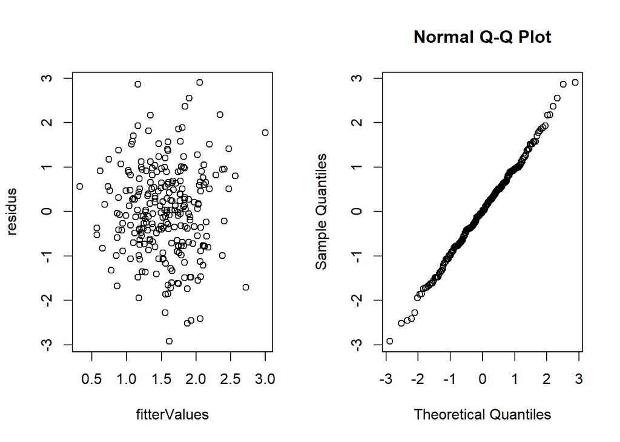

```r
#valors residus
residus <- rstandard(model.linearRegression)
#valors ajustats
fitterValues <- fitted(model.linearRegression)

#plot fitterValues and qqnorm
par(mfrow=c(1,2))
plot(fitterValues, residus)
qqnorm(residus)
```

En el primer gràfic s’observar un patró de dispersió bastant regular, com a tal podem determinar que tenim una variança constant. D’altra banda el QQ plot, mostra que les dades s’ajusten bé a una distribució de tipus normal.

## 6.4 Predicció

```r
#age and smokerTypes sequences
ageRange <- seq(30, 80, by=1)
smokerTypes.names <- c("NF","FP","NI","FL","FM","FI")
d<-data.frame(NF=c(), FP=c(), NI=c(), FL=c(), FM=c(), FI=c())

#loop per each type-age
for(i in ageRange){
  v <- numeric()
  v <- append(v,i)
  for(j in smokerTypes.names){
    newdata = data.frame(Tipo=j, edad=i, genero="M")
    predictedValue <- predict(model.linearRegression, newdata)
    v<-append(v,predictedValue)
  }
  #adding to df
  d<-structure(rbind(d,v), .Names = names(smokerTypes.names))
}
#colnames
colnames(d)<-c("age",smokerTypes.names)

#table construcction
kable(d, digits=3, caption="Prediccions de la capacitat pulmonar per tipus de fumadors dels 30 als 80 anys")
```

Prediccions de la capacitat pulmonar per tipus de fumadors dels 30 als 80 anys

| age | NF | FP | NI | FL | FM | FI |
| --- | --- | --- | --- | --- | --- | --- |
| 30 | 2.593 | 2.206 | 2.235 | 2.150 | 1.858 | 1.812 |
| 31 | 2.563 | 2.175 | 2.204 | 2.119 | 1.827 | 1.781 |
| 32 | 2.532 | 2.144 | 2.173 | 2.089 | 1.796 | 1.750 |
| 33 | 2.501 | 2.113 | 2.142 | 2.058 | 1.765 | 1.719 |
| 34 | 2.470 | 2.082 | 2.111 | 2.027 | 1.734 | 1.688 |
| 35 | 2.439 | 2.051 | 2.080 | 1.996 | 1.703 | 1.657 |
| 36 | 2.408 | 2.020 | 2.049 | 1.965 | 1.672 | 1.626 |
| 37 | 2.377 | 1.989 | 2.019 | 1.934 | 1.641 | 1.595 |
| 38 | 2.346 | 1.958 | 1.988 | 1.903 | 1.610 | 1.564 |
| 39 | 2.315 | 1.927 | 1.957 | 1.872 | 1.580 | 1.533 |
| 40 | 2.284 | 1.896 | 1.926 | 1.841 | 1.549 | 1.502 |
| 41 | 2.253 | 1.865 | 1.895 | 1.810 | 1.518 | 1.471 |
| 42 | 2.222 | 1.834 | 1.864 | 1.779 | 1.487 | 1.440 |
| 43 | 2.191 | 1.804 | 1.833 | 1.748 | 1.456 | 1.409 |
| 44 | 2.160 | 1.773 | 1.802 | 1.717 | 1.425 | 1.379 |
| 45 | 2.129 | 1.742 | 1.771 | 1.686 | 1.394 | 1.348 |
| 46 | 2.098 | 1.711 | 1.740 | 1.655 | 1.363 | 1.317 |
| 47 | 2.068 | 1.680 | 1.709 | 1.624 | 1.332 | 1.286 |
| 48 | 2.037 | 1.649 | 1.678 | 1.593 | 1.301 | 1.255 |
| 49 | 2.006 | 1.618 | 1.647 | 1.563 | 1.270 | 1.224 |
| 50 | 1.975 | 1.587 | 1.616 | 1.532 | 1.239 | 1.193 |
| 51 | 1.944 | 1.556 | 1.585 | 1.501 | 1.208 | 1.162 |
| 52 | 1.913 | 1.525 | 1.554 | 1.470 | 1.177 | 1.131 |
| 53 | 1.882 | 1.494 | 1.523 | 1.439 | 1.146 | 1.100 |
| 54 | 1.851 | 1.463 | 1.493 | 1.408 | 1.115 | 1.069 |
| 55 | 1.820 | 1.432 | 1.462 | 1.377 | 1.084 | 1.038 |
| 56 | 1.789 | 1.401 | 1.431 | 1.346 | 1.054 | 1.007 |
| 57 | 1.758 | 1.370 | 1.400 | 1.315 | 1.023 | 0.976 |
| 58 | 1.727 | 1.339 | 1.369 | 1.284 | 0.992 | 0.945 |
| 59 | 1.696 | 1.308 | 1.338 | 1.253 | 0.961 | 0.914 |
| 60 | 1.665 | 1.278 | 1.307 | 1.222 | 0.930 | 0.883 |
| 61 | 1.634 | 1.247 | 1.276 | 1.191 | 0.899 | 0.853 |
| 62 | 1.603 | 1.216 | 1.245 | 1.160 | 0.868 | 0.822 |
| 63 | 1.572 | 1.185 | 1.214 | 1.129 | 0.837 | 0.791 |
| 64 | 1.542 | 1.154 | 1.183 | 1.098 | 0.806 | 0.760 |
| 65 | 1.511 | 1.123 | 1.152 | 1.067 | 0.775 | 0.729 |
| 66 | 1.480 | 1.092 | 1.121 | 1.037 | 0.744 | 0.698 |
| 67 | 1.449 | 1.061 | 1.090 | 1.006 | 0.713 | 0.667 |
| 68 | 1.418 | 1.030 | 1.059 | 0.975 | 0.682 | 0.636 |
| 69 | 1.387 | 0.999 | 1.028 | 0.944 | 0.651 | 0.605 |
| 70 | 1.356 | 0.968 | 0.997 | 0.913 | 0.620 | 0.574 |
| 71 | 1.325 | 0.937 | 0.967 | 0.882 | 0.589 | 0.543 |
| 72 | 1.294 | 0.906 | 0.936 | 0.851 | 0.558 | 0.512 |
| 73 | 1.263 | 0.875 | 0.905 | 0.820 | 0.528 | 0.481 |
| 74 | 1.232 | 0.844 | 0.874 | 0.789 | 0.497 | 0.450 |
| 75 | 1.201 | 0.813 | 0.843 | 0.758 | 0.466 | 0.419 |
| 76 | 1.170 | 0.782 | 0.812 | 0.727 | 0.435 | 0.388 |
| 77 | 1.139 | 0.752 | 0.781 | 0.696 | 0.404 | 0.357 |
| 78 | 1.108 | 0.721 | 0.750 | 0.665 | 0.373 | 0.327 |
| 79 | 1.077 | 0.690 | 0.719 | 0.634 | 0.342 | 0.296 |
| 80 | 1.046 | 0.659 | 0.688 | 0.603 | 0.311 | 0.265 |

# 7 ANOVA unifactorial

En aquest apartat realitzarem un anàlisi de la variància per contrastar si existeixen diferències en la capacitat pulmonar i els sis tipus de fumadors/no fumadors.

## 7.1 Normalitat

Avalueu si el conjunt de dades compleix les condicions d’aplicació d’ANOVA fent ús del gràfic Normal Q-Q i el test Shapiro-Wilk.

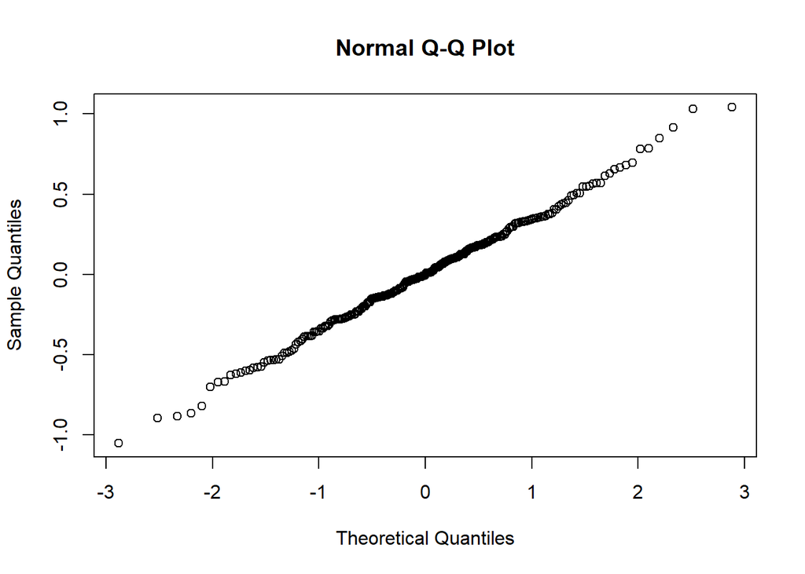

```r
# Normal Q-Q
qqnorm(residuals(model.linearRegression))
```

```r
#Test Shapiro-Wilk
shapiro.test(residuals(model.linearRegression))
```

```
##
##  Shapiro-Wilk normality test
##
## data:  residuals(model.linearRegression)
## W = 0.99707, p-value = 0.9258
```

En el gràfic del Normal Q-Q podem observar que aparentment hi ha compliment de la normalitat. En el cas del test Shapiro-Wilk, el *pvalor* és molt elevat i, per tant, acceptem la hipòtesi nul·la de normalitat.

## 7.3 Hipòtesi nul·la i alternativa

$$H_0: AE_{NF} = AE_{FP} = AE_{NI} = AE_{FL} = AE_{FM} = AE_{FI}$$
$$H_1: AE_{i} \neq AE_{j} \ \ \ \ per \ algun\ \ i,j$$

## 7.4 Càlcul ANOVA

```r
#ANOVA model
model.anova.unifactorial <- aov(AE~Tipo, df)
```

## 7.5 Interpretació

```r
#model's summary
summary(model.anova.unifactorial)
```

```
##              Df Sum Sq Mean Sq F value   Pr(>F)
## Tipo          5  20.86   4.171   17.88 4.03e-15 ***
## Residuals   247  57.63   0.233
## ---
## Signif. codes:  0 '***' 0.001 '**' 0.01 '*' 0.05 '.' 0.1 ' ' 1
```

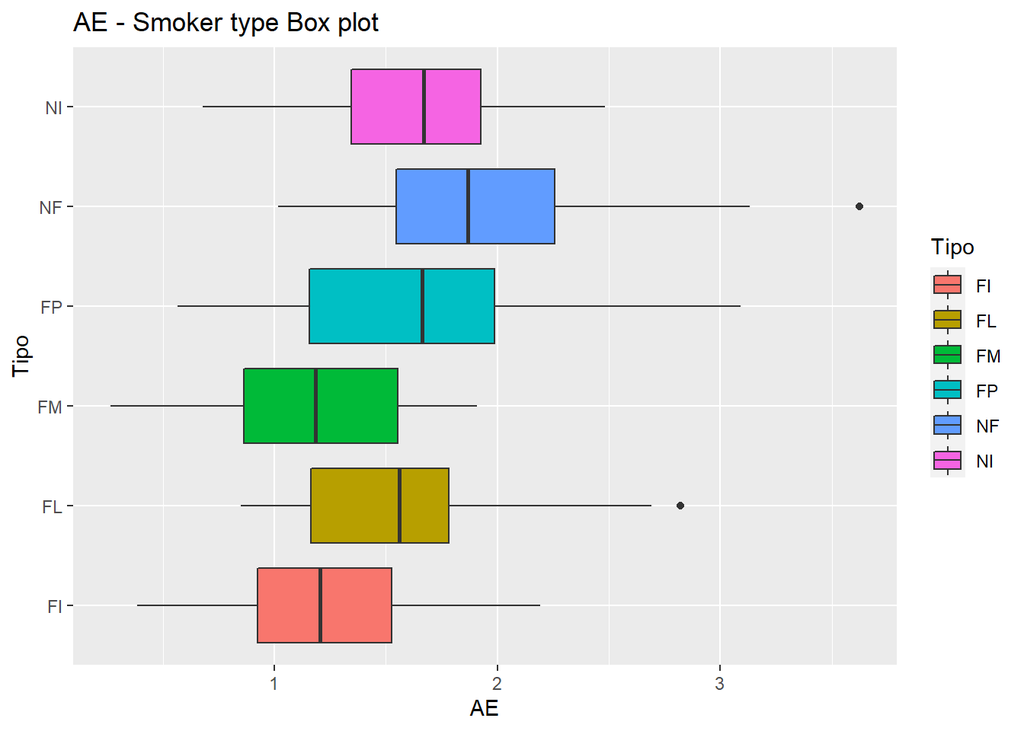

```r
#Box plot AE by Tipo
ggplot(df, aes(x=AE, y=Tipo, fill=Tipo)) + geom_boxplot() + guides() + ggtitle("AE - Smoker type Box plot")
```

Podem observar els següents valors de contrast: *Sum Sq* = 20.85; *Mean Sq* = 4.17; *F* = 17.87; *pvalor* = 4.026e-15. El *pvalor* és molt petit, inferior al nivell de significança 0.05. La conclusió que podem extreure, és que el factor que estem analitzant és significatiu. Per tant, rebutgem la hipòtesi nul·la d’igualtat de mitjanes entre els diferents grups de fumadors/no fumadors. A la vegada, aquest fet el podem acabar de reafirmar considerant el diagrama de caixes realitzat anteriorment.

# 8 Comparacions múltiples

## 8.1 Test pairwise

Mitjançant el test pairwise, podem realitzar proves de tipus t entre parells. Això ens permet calcular les diferències entre parells de la capacitat pulmonar de cada tipus.

```r
## Test pairwise
pairwise.t.test (df$AE, df$Tipo, p.adjust.method = "none")
```

```
##
##  Pairwise comparisons using t tests with pooled SD
##
## data:  df$AE and df$Tipo
##
##    FI      FL      FM      FP      NF
## FL 0.00165 -       -       -       -
## FM 0.58175 0.00027 -       -       -
## FP 0.00021 0.54864 2.9e-05 -       -
## NF 5.4e-13 2.6e-05 2.6e-14 0.00035 -
## NI 0.00011 0.46122 1.3e-05 0.89733 0.00048
##
## P value adjustment method: none
```

## 8.2 Correcció de Bonferroni

A continuació realitzarem el mateix tipus de test aplicant la correcció de Bonferroni.

```r
## Correcció de Bonferroni
#src: https://statologos.com/correccion-de-bonferroni-en-r/
pairwise.t.test (df$AE, df$Tipo, p.adjust.method = "bonferroni")
```

```
##
##  Pairwise comparisons using t tests with pooled SD
##
## data:  df$AE and df$Tipo
##
##    FI      FL      FM      FP      NF
## FL 0.02477 -       -       -       -
## FM 1.00000 0.00409 -       -       -
## FP 0.00315 1.00000 0.00043 -       -
## NF 8.1e-12 0.00039 4.0e-13 0.00522 -
## NI 0.00160 1.00000 0.00020 1.00000 0.00717
##
## P value adjustment method: bonferroni
```